# Pemodelan ARIMA - Pendugaan Parameter, Diagnostik Model, dan Peramalan

Author

Siti Farah Fadilah X1004261005

Published

September 25, 2026

## 1 Packages

```r
library(ggplot2)
library(tsibble)
library(tseries)
library(MASS)
library(forecast)
library(TSA)
library(TTR)
library(aTSA)
library(graphics)
```

## 2 Data Penumpang Transportasi Umum Malaysia

### 2.1 Input Data

Data yang digunakan adalah data jumlah penumpang transportasi umum Malaysia harian (kolom `Farah`) sebanyak 100 periode, mulai 19 Maret 2025 sampai 26 Juni 2025.

```r
data <- read.csv("data jumlah penumpang transportasi umum malaysia_FARAH.csv")
str(data)
```

```
'data.frame':   100 obs. of  3 variables:
 $ Periode: int  501 502 503 504 505 506 507 508 509 510 ...
 $ Tanggal: chr  "3/19/2025" "3/20/2025" "3/21/2025" "3/22/2025" ...
 $ Farah  : int  56787 56784 59951 48275 43641 55309 56098 56386 55191 58493 ...
```

```r
dat.ts <- ts(data$Farah)
dat.ts
```

```
Time Series:
Start = 1
End = 100
Frequency = 1
  [1] 56787 56784 59951 48275 43641 55309 56098 56386 55191 58493 47300 54527
 [13] 63542 58783 55285 52397 50295 41095 42329 54565 56016 55590 56618 60289
 [25] 48874 47020 58917 59803 62982 61465 63559 52567 46891 58806 59187 58651
 [37] 59267 62226 51168 45702 58492 58142 62445 51892 62407 53680 45313 59914
 [49] 59605 60206 60569 62674 55656 58142 46499 59407 58814 59898 61306 49403
 [61] 42852 57035 58811 60208 60620 65132 56059 46670 54785 56716 60401 62840
 [73] 66455 59536 63271 48644 61195 60373 60136 59910 61041 54318 56409 58405
 [85] 59653 58792 61824 51582 45601 57615 58409 59505 57890 62276 47895 45718
 [97] 56785 56860 58354 59612
```

Data kemudian dibagi menjadi data latih dan data uji. Karena jumlah periode terbatas (100 observasi), pembagian dilakukan dengan proporsi 90:10 agar model memperoleh data latih yang cukup banyak.

```r
n <- nrow(data)
n.train <- 90

train.ts <- ts(data$Farah[1:n.train])
test.ts  <- ts(data$Farah[(n.train+1):n])
```

### 2.2 Eksplorasi Data

Sebelum masuk dalam tahap pemodelan, dilakukan eksplorasi data dengan plot deret waktu untuk melihat pola data.

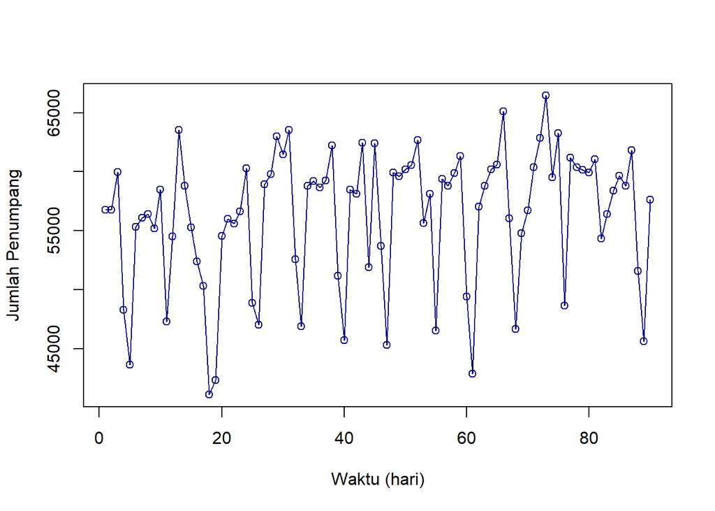

```r
#--PLOT TIME SERIES--#
plot(train.ts,
     col = "navyblue",
     lwd = 1,
     type = "o",
     xlab = "Waktu (hari)",
     ylab = "Jumlah Penumpang")
```

Berdasarkan plot data deret waktu di atas, data cenderung bergerak di sekitar nilai tengahnya tanpa memperlihatkan tren naik/turun yang jelas, dengan lebar pita yang relatif konsisten sepanjang waktu. Hal ini menjadi indikasi awal bahwa data sudah stasioner dalam rataan dan ragam. Selain dengan plot data deret waktu, akan dilakukan pengecekan stasioneritas data dengan plot ACF dan uji ADF.

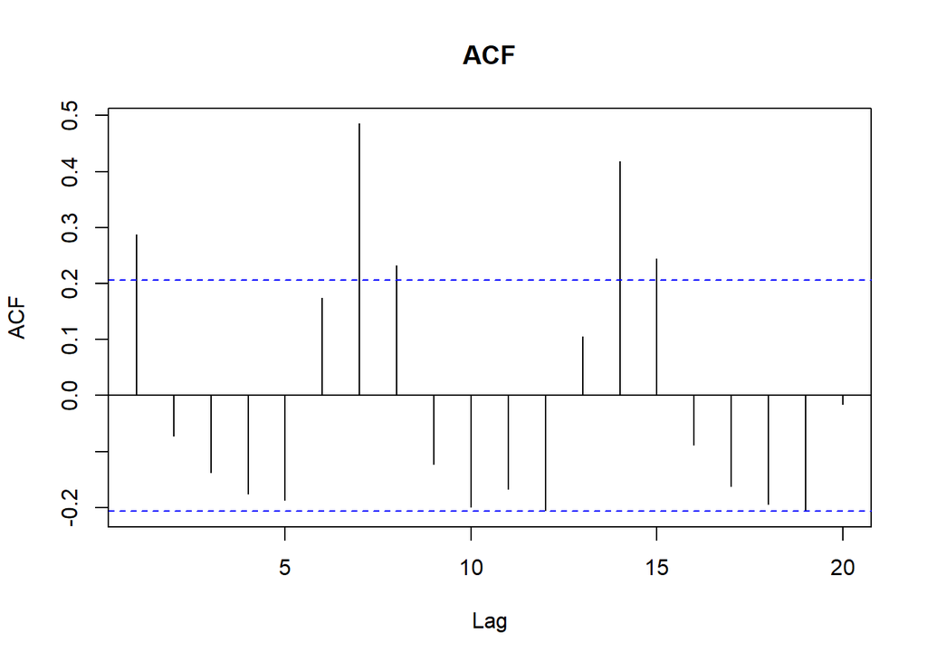

```r
#--CEK KESTASIONERAN---#
acf(train.ts, main="ACF", lag.max=20)
```

```r
tseries::adf.test(train.ts)
```

```
    Augmented Dickey-Fuller Test

data:  train.ts
Dickey-Fuller = -6.6544, Lag order = 4, p-value = 0.01
alternative hypothesis: stationary
```

```r
#stasioner
```

$H_0$ : Data tidak stasioner dalam rataan

$H_1$ : Data stasioner dalam rataan

Berdasarkan uji ADF tersebut, didapat *p-value* sebesar 0.01 yang lebih kecil dari taraf nyata 5% sehingga tolak $H_0$ dan menandakan bahwa data stasioner dalam rataan. Hal ini sesuai dengan hasil eksplorasi menggunakan plot time series, sehingga data dapat langsung dimodelkan tanpa proses *differencing*.

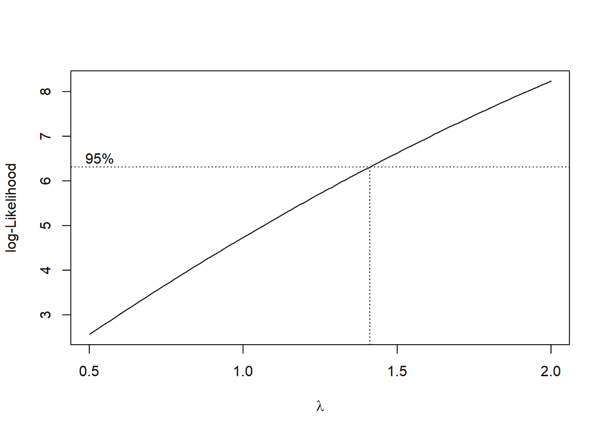

```r
index <- seq(1:n.train)

# Box-Cox
bc <- boxcox(
  train.ts~index,
  lambda = seq(0.5, 2, by = 0.1)
)
```

```r
# Nilai lambda optimum
lambda <- bc$x[which.max(bc$y)]
lambda
```

```
[1] 2
```

```r
# Selang kepercayaan 95% untuk lambda
ci_lambda <- bc$x[bc$y > max(bc$y) - 0.5 * qchisq(0.95, 1)]

# Batas bawah dan batas atas
ci_lower <- min(ci_lambda)
ci_upper <- max(ci_lambda)

c(Batas_Bawah = ci_lower, Batas_Atas = ci_upper)
```

```
Batas_Bawah  Batas_Atas
   1.424242    2.000000
```

Nilai *rounded value* ($\lambda$) optimum yang diperoleh berada pada batas atas rentang pengujian (2) dengan selang kepercayaan 95% antara 1,42 dan 2, sehingga selang tersebut tidak memuat nilai satu. Meskipun demikian, secara visual pada plot data deret waktu tidak terlihat pola pelebaran/penyempitan pita data yang jelas terhadap waktu, sehingga data tetap dianggap cukup stasioner dalam ragam untuk dilanjutkan ke tahap pemodelan tanpa transformasi.

### 2.3 Spesifikasi Model

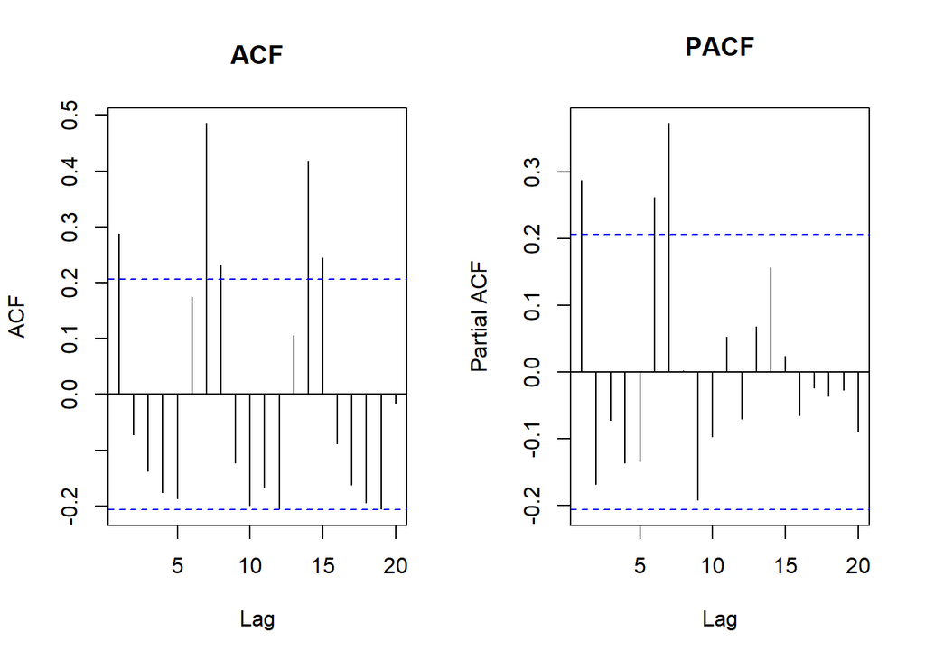

```r
#---SPESIFIKASI MODEL---#
par(mfrow = c(1,2))
acf(train.ts, main="ACF", lag.max=20) #ARIMA(0,0,1)
pacf(train.ts, main="PACF", lag.max=20) #ARIMA(1,0,0)
```

```r
par(mfrow = c(1,1))
```

```r
eacf(train.ts)
```

```
AR/MA
  0 1 2 3 4 5 6 7 8 9 10 11 12 13
0 x o o o o o x x o o o  o  o  x
1 x o o o o o x x o o o  o  o  x
2 x o o o o o x o o o o  o  o  o
3 x x o o o o x o o o o  o  o  o
4 x o o x o o o o o o o  o  o  o
5 x x x x o o o o o o o  o  o  o
6 x x x o o o o o o o o  o  o  o
7 o x o o x o x o o o o  o  o  o
```

```r
#ARIMA(0,0,1) #ARIMA(1,0,0) #ARIMA(1,0,1) #ARIMA(0,0,2) #ARIMA(0,0,5)
#Terdapat beberapa model tentatif
```

Menggunakan plot EACF, dapat diambil beberapa model tentatif dengan melihat ujung segitiga pola nol yang terbentuk, antara lain ARIMA(0,0,1), ARIMA(1,0,0), ARIMA(1,0,1), dan ARIMA(0,0,2). Sebagai pembanding tambahan, ditambahkan pula model ARIMA(0,0,5) yang teridentifikasi pada orde MA lebih tinggi.

### 2.4 Pendugaan Parameter

Selanjutnya akan dilakukan pendugaan parameter kelima model ARIMA yang terbentuk sebelumnya. Pendugaan dilakukan dengan fungsi `Arima()` yang dilanjutkan dengan melihat nilai AIC pada ringkasan data dan melihat signifikansi parameter.

```r
#---PENDUGAAN PARAMETER MODEL---#
model1=Arima(train.ts, order=c(1,0,0),method="ML")
summary(model1) #AIC=1811.70
```

```
Series: train.ts
ARIMA(1,0,0) with non-zero mean

Coefficients:
         ar1        mean
      0.2847  56274.0925
s.e.  0.1003    806.7642

sigma^2 = 30922258:  log likelihood = -902.85
AIC=1811.7   AICc=1811.98   BIC=1819.2

Training set error measures:
                    ME     RMSE      MAE       MPE     MAPE      MASE
Training set -1.432697 5498.645 4526.763 -1.074984 8.528953 0.8697194
                   ACF1
Training set 0.05148656
```

```r
lmtest::coeftest(model1) #seluruh parameter signifikan
```

```
z test of coefficients:

            Estimate Std. Error z value  Pr(>|z|)
ar1       2.8471e-01 1.0031e-01  2.8383  0.004535 **
intercept 5.6274e+04 8.0676e+02 69.7528 < 2.2e-16 ***
---
Signif. codes:  0 '***' 0.001 '**' 0.01 '*' 0.05 '.' 0.1 ' ' 1
```

```r
model2=Arima(train.ts, order=c(0,0,1),method="ML")
summary(model2) #AIC=1809.92
```

```
Series: train.ts
ARIMA(0,0,1) with non-zero mean

Coefficients:
         ma1        mean
      0.3376  56285.5405
s.e.  0.0978    765.3783

sigma^2 = 30304164:  log likelihood = -901.96
AIC=1809.92   AICc=1810.2   BIC=1817.42

Training set error measures:
                   ME     RMSE      MAE       MPE     MAPE      MASE
Training set -2.61403 5443.412 4451.931 -1.050455 8.366994 0.8553422
                     ACF1
Training set -0.001073693
```

```r
lmtest::coeftest(model2) #seluruh parameter signifikan
```

```
z test of coefficients:

            Estimate Std. Error z value  Pr(>|z|)
ma1       3.3756e-01 9.7779e-02  3.4522  0.000556 ***
intercept 5.6286e+04 7.6538e+02 73.5395 < 2.2e-16 ***
---
Signif. codes:  0 '***' 0.001 '**' 0.01 '*' 0.05 '.' 0.1 ' ' 1
```

```r
model3=Arima(train.ts, order=c(1,0,1),method="ML")
summary(model3) #AIC=1811.91
```

```
Series: train.ts
ARIMA(1,0,1) with non-zero mean

Coefficients:
          ar1     ma1        mean
      -0.0279  0.3609  56285.5955
s.e.   0.2571  0.2335    757.6683

sigma^2 = 30648744:  log likelihood = -901.95
AIC=1811.91   AICc=1812.38   BIC=1821.91

Training set error measures:
                    ME    RMSE      MAE       MPE     MAPE   MASE        ACF1
Training set -2.796329 5443.08 4449.109 -1.052159 8.361042 0.8548 0.002616232
```

```r
lmtest::coeftest(model3) #ar1 dan ma1 tidak signifikan
```

```
z test of coefficients:

             Estimate  Std. Error z value Pr(>|z|)
ar1       -2.7914e-02  2.5712e-01 -0.1086   0.9135
ma1        3.6092e-01  2.3352e-01  1.5456   0.1222
intercept  5.6286e+04  7.5767e+02 74.2879   <2e-16 ***
---
Signif. codes:  0 '***' 0.001 '**' 0.01 '*' 0.05 '.' 0.1 ' ' 1
```

```r
model4=Arima(train.ts, order=c(0,0,2),method="ML")
summary(model4) #AIC=1811.90
```

```
Series: train.ts
ARIMA(0,0,2) with non-zero mean

Coefficients:
         ma1      ma2        mean
      0.3299  -0.0157  56285.5969
s.e.  0.1110   0.1123    752.1141

sigma^2 = 30646239:  log likelihood = -901.95
AIC=1811.9   AICc=1812.37   BIC=1821.9

Training set error measures:
                   ME     RMSE      MAE       MPE     MAPE      MASE
Training set -2.83933 5442.858 4446.933 -1.053139 8.356491 0.8543819
                    ACF1
Training set 0.005162945
```

```r
lmtest::coeftest(model4) #ma2 tidak signifikan
```

```
z test of coefficients:

             Estimate  Std. Error z value  Pr(>|z|)
ma1           0.32985     0.11103  2.9707  0.002971 **
ma2          -0.01570     0.11232 -0.1398  0.888838
intercept 56285.59695   752.11410 74.8365 < 2.2e-16 ***
---
Signif. codes:  0 '***' 0.001 '**' 0.01 '*' 0.05 '.' 0.1 ' ' 1
```

```r
model5=Arima(train.ts, order=c(0,0,5),method="ML")
summary(model5) #AIC=1808.23
```

```
Series: train.ts
ARIMA(0,0,5) with non-zero mean

Coefficients:
         ma1     ma2     ma3      ma4      ma5        mean
      0.2562  0.1997  0.1518  -0.1042  -0.4145  56319.5428
s.e.  0.0910  0.1009  0.1124   0.1188   0.1070    596.8053

sigma^2 = 28117276:  log likelihood = -897.11
AIC=1808.23   AICc=1809.59   BIC=1825.73

Training set error measures:
                    ME     RMSE      MAE        MPE    MAPE      MASE      ACF1
Training set -29.70073 5122.772 4177.992 -0.9603997 7.84808 0.8027106 0.0320332
```

```r
lmtest::coeftest(model5) #ma3 dan ma4 tidak signifikan
```

```
z test of coefficients:

             Estimate  Std. Error z value  Pr(>|z|)
ma1        2.5616e-01  9.1047e-02  2.8135  0.004900 **
ma2        1.9967e-01  1.0095e-01  1.9779  0.047939 *
ma3        1.5183e-01  1.1237e-01  1.3512  0.176644
ma4       -1.0421e-01  1.1876e-01 -0.8775  0.380201
ma5       -4.1449e-01  1.0699e-01 -3.8741  0.000107 ***
intercept  5.6320e+04  5.9681e+02 94.3684 < 2.2e-16 ***
---
Signif. codes:  0 '***' 0.001 '**' 0.01 '*' 0.05 '.' 0.1 ' ' 1
```

```r
#model yang dipilih adalah model 2, yaitu ARIMA(0,0,1)
```

```r
hasil_model <- data.frame(
  Model = c("ARIMA(1,0,0)",
            "ARIMA(0,0,1)",
            "ARIMA(1,0,1)",
            "ARIMA(0,0,2)",
            "ARIMA(0,0,5)"),
  AIC = c(
    AIC(model1),
    AIC(model2),
    AIC(model3),
    AIC(model4),
    AIC(model5)
  ),
  BIC = c(
    BIC(model1),
    BIC(model2),
    BIC(model3),
    BIC(model4),
    BIC(model5)
  )
)

hasil_model
```

```
         Model      AIC      BIC
1 ARIMA(1,0,0) 1811.700 1819.199
2 ARIMA(0,0,1) 1809.919 1817.418
3 ARIMA(1,0,1) 1811.907 1821.906
4 ARIMA(0,0,2) 1811.899 1821.898
5 ARIMA(0,0,5) 1808.229 1825.728
```

Berdasarkan pendugaan parameter di atas, model ARIMA(0,0,5) memiliki AIC terkecil, namun tidak seluruh parameternya signifikan (ma3 dan ma4 tidak signifikan) dan memiliki BIC yang lebih besar dibandingkan model yang lebih sederhana. Model ARIMA(0,0,1) memiliki AIC dan BIC yang rendah sekaligus seluruh parameternya signifikan, sehingga model yang dipilih adalah model ARIMA(0,0,1).

### 2.5 Analisis Sisaan

Model terbaik hasil identifikasi kemudian dicek asumsi sisaannya. Sisaan model ARIMA harus memenuhi asumsi normalitas, kebebasan, dan kehomogenan ragam. Diagnostik model dilakukan secara eksplorasi dan uji formal.

#### 2.5.1 Eksplorasi Sisaan

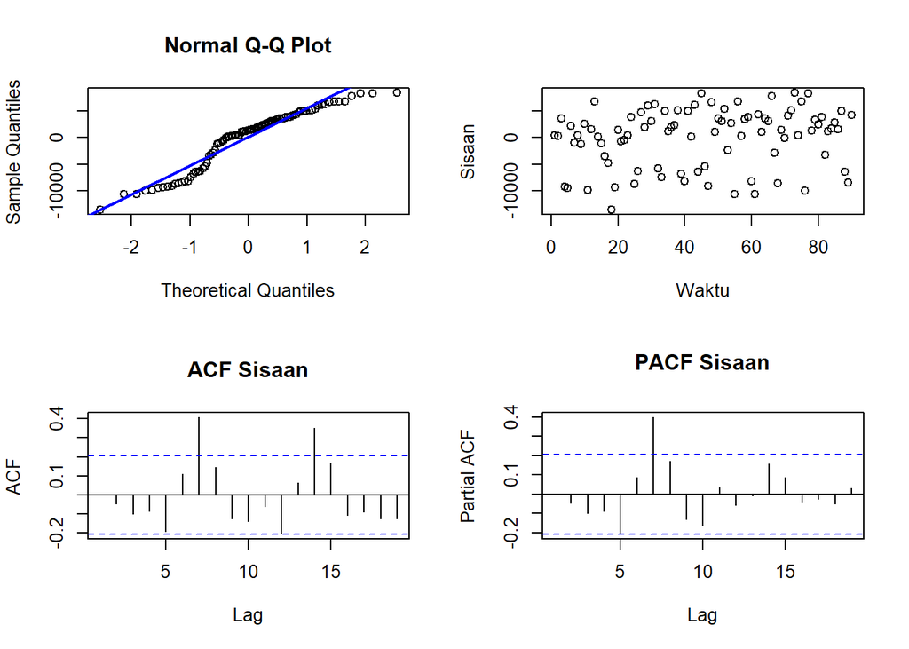

```r
#Eksplorasi
sisaan <- model2$residuals
par(mfrow=c(2,2))

qqnorm(sisaan, main = "Normal Q-Q Plot")
qqline(sisaan, col = "blue", lwd = 2)
plot(c(1:length(sisaan)), sisaan, xlab = "Waktu", ylab = "Sisaan")

# ACF dan PACF sisaan
acf(sisaan, main = "ACF Sisaan")
pacf(sisaan, main = "PACF Sisaan")
```

```r
par(mfrow = c(1,1))
```

Berdasarkan plot kuantil-kuantil normal, terlihat titik-titik di ekor bawah dan atas menyimpang dari garis $45^{\circ}$, mengindikasikan sisaan belum sepenuhnya menyebar normal. Plot sisaan terhadap waktu tidak memperlihatkan pola pelebaran pita yang jelas. Sementara itu, plot ACF dan PACF sisaan ARIMA(0,0,1) menunjukkan lonjakan yang mendekati/melewati batas signifikansi pada sekitar lag ke-7, konsisten dengan kemungkinan pola mingguan pada data penumpang harian, meskipun di luar cakupan model ARIMA non-musiman pada praktikum ini. Kondisi ini akan diuji lebih lanjut dengan uji formal.

#### 2.5.2 Uji Formal

```r
#1) Sisaan Menyebar Normal
ks.test(sisaan,"pnorm", mean(sisaan), sd(sisaan))
```

```
    Exact one-sample Kolmogorov-Smirnov test

data:  sisaan
D = 0.15699, p-value = 0.02103
alternative hypothesis: two-sided
```

```r
#tolak H0 > sisaan tidak menyebar normal
```

Selain dengan eksplorasi, asumsi tersebut dapat diuji menggunakan uji formal. Pada tahapan ini uji formal yang digunakan untuk normalitas adalah uji Kolmogorov-Smirnov (KS). Hipotesis pada uji KS adalah sebagai berikut.

$H_0$ : Sisaan menyebar normal

$H_1$ : Sisaan tidak menyebar normal

Berdasarkan uji KS tersebut, didapat *p-value* sebesar 0,021 yang lebih kecil dari taraf nyata 5% sehingga tolak $H_0$ dan menandakan bahwa sisaan tidak menyebar normal. Hal ini sesuai dengan hasil eksplorasi menggunakan plot kuantil-kuantil normal.

```r
#2) Sisaan saling bebas/tidak ada autokorelasi
Box.test(sisaan, type = "Ljung")
```

```
    Box-Ljung test

data:  sisaan
X-squared = 0.00010725, df = 1, p-value = 0.9917
```

```r
#gagal tolak H0 > sisaan saling bebas
```

Selanjutnya akan dilakukan uji formal untuk kebebasan sisaan menggunakan uji Ljung-Box. Hipotesis yang digunakan adalah sebagai berikut.

$H_0$ : Sisaan saling bebas

$H_1$ : Sisaan tidak saling bebas

Berdasarkan uji Ljung-Box tersebut, didapat *p-value* sebesar 0,992 yang lebih besar dari taraf nyata 5% sehingga gagal tolak $H_0$ dan menandakan bahwa sisaan saling bebas secara keseluruhan (lag ke-1).

```r
#3) Sisaan homogen
Box.test((sisaan)^2, type = "Ljung")
```

```
    Box-Ljung test

data:  (sisaan)^2
X-squared = 3.4472, df = 1, p-value = 0.06336
```

```r
#gagal tolak H0 > ragam sisaan homogen
```

Hipotesis yang digunakan untuk uji kehomogenan ragam adalah sebagai berikut.

$H_0$ : Ragam sisaan homogen

$H_1$ : Ragam sisaan tidak homogen

Berdasarkan uji Ljung-Box terhadap sisaan kuadrat tersebut, didapat *p-value* sebesar 0,063 yang lebih besar dari taraf nyata 5% sehingga gagal tolak $H_0$ dan menandakan bahwa ragam sisaan homogen, meskipun nilainya mendekati batas taraf nyata.

```r
#4) Nilai tengah sisaan sama dengan nol
t.test(sisaan, mu = 0, conf.level = 0.95)
```

```
    One Sample t-test

data:  sisaan
t = -0.0045304, df = 89, p-value = 0.9964
alternative hypothesis: true mean is not equal to 0
95 percent confidence interval:
 -1149.102  1143.874
sample estimates:
mean of x
 -2.61403
```

```r
#gagal tolak H0 > nilai tengah sisaan sama dengan 0
```

Terakhir, dengan uji-t, akan dicek apakah nilai tengah sisaan sama dengan nol. Hipotesis yang diujikan sebagai berikut.

$H_0$ : nilai tengah sisaan sama dengan 0

$H_1$ : nilai tengah sisaan tidak sama dengan 0

Berdasarkan uji-t tersebut, didapat *p-value* sebesar 0,996 yang lebih besar dari taraf nyata 5% sehingga gagal tolak $H_0$ dan menandakan bahwa nilai tengah sisaan sama dengan nol.

### 2.6 Overfitting

Tahapan selanjutnya adalah *overfitting* dilakukan dengan menaikkan orde AR(p) dan MA(q) dari model ARIMA(0,0,1) untuk melihat apakah terdapat model lain yang lebih baik dari model saat ini. Kandidat model *overfitting* adalah ARIMA(1,0,1) dan ARIMA(0,0,2).

```r
#---OVERFITTING---#
model2a=Arima(train.ts, order=c(1,0,1),method="ML")
summary(model2a) #AIC=1811.91
```

```
Series: train.ts
ARIMA(1,0,1) with non-zero mean

Coefficients:
          ar1     ma1        mean
      -0.0279  0.3609  56285.5955
s.e.   0.2571  0.2335    757.6683

sigma^2 = 30648744:  log likelihood = -901.95
AIC=1811.91   AICc=1812.38   BIC=1821.91

Training set error measures:
                    ME    RMSE      MAE       MPE     MAPE   MASE        ACF1
Training set -2.796329 5443.08 4449.109 -1.052159 8.361042 0.8548 0.002616232
```

```r
lmtest::coeftest(model2a) #ar1 dan ma1 tidak signifikan
```

```
z test of coefficients:

             Estimate  Std. Error z value Pr(>|z|)
ar1       -2.7914e-02  2.5712e-01 -0.1086   0.9135
ma1        3.6092e-01  2.3352e-01  1.5456   0.1222
intercept  5.6286e+04  7.5767e+02 74.2879   <2e-16 ***
---
Signif. codes:  0 '***' 0.001 '**' 0.01 '*' 0.05 '.' 0.1 ' ' 1
```

```r
model2b=Arima(train.ts, order=c(0,0,2),method="ML")
summary(model2b) #AIC=1811.90
```

```
Series: train.ts
ARIMA(0,0,2) with non-zero mean

Coefficients:
         ma1      ma2        mean
      0.3299  -0.0157  56285.5969
s.e.  0.1110   0.1123    752.1141

sigma^2 = 30646239:  log likelihood = -901.95
AIC=1811.9   AICc=1812.37   BIC=1821.9

Training set error measures:
                   ME     RMSE      MAE       MPE     MAPE      MASE
Training set -2.83933 5442.858 4446.933 -1.053139 8.356491 0.8543819
                    ACF1
Training set 0.005162945
```

```r
lmtest::coeftest(model2b) #ma2 tidak signifikan
```

```
z test of coefficients:

             Estimate  Std. Error z value  Pr(>|z|)
ma1           0.32985     0.11103  2.9707  0.002971 **
ma2          -0.01570     0.11232 -0.1398  0.888838
intercept 56285.59695   752.11410 74.8365 < 2.2e-16 ***
---
Signif. codes:  0 '***' 0.001 '**' 0.01 '*' 0.05 '.' 0.1 ' ' 1
```

```r
#model yang dipilih adalah model awal, yaitu ARIMA(0,0,1)
```

```r
overfitting <- data.frame(
  Model = c("ARIMA(1,0,1)","ARIMA(0,0,1)", "ARIMA(0,0,2)"),
  AIC   = c(AIC(model2a),AIC(model2), AIC(model2b)),
  BIC   = c(BIC(model2a),BIC(model2), BIC(model2b))
)

overfitting
```

```
         Model      AIC      BIC
1 ARIMA(1,0,1) 1811.907 1821.906
2 ARIMA(0,0,1) 1809.919 1817.418
3 ARIMA(0,0,2) 1811.899 1821.898
```

Berdasarkan kedua model hasil *overfitting* di atas, AIC dan BIC model ARIMA(1,0,1) dan ARIMA(0,0,2) tidak lebih baik dibandingkan model ARIMA(0,0,1), dan parameter tambahan pada kedua model tersebut tidak signifikan. Oleh karena itu, model ARIMA(0,0,1) tetap digunakan untuk melakukan peramalan.

### 2.7 Peramalan

Peramalan dilakukan menggunakan fungsi `forecast()`. Peramalan berikut ini dilakukan sepanjang data uji, yaitu 10 hari ke depan.

```r
#---FORECAST---#
ramalan <- forecast::forecast(model2, h = length(test.ts))
ramalan
```

```
    Point Forecast    Lo 80    Hi 80    Lo 95    Hi 95
 91       57705.79 50650.95 64760.63 46916.34 68495.24
 92       56285.54 48839.61 63731.47 44897.97 67673.11
 93       56285.54 48839.61 63731.47 44897.97 67673.11
 94       56285.54 48839.61 63731.47 44897.97 67673.11
 95       56285.54 48839.61 63731.47 44897.97 67673.11
 96       56285.54 48839.61 63731.47 44897.97 67673.11
 97       56285.54 48839.61 63731.47 44897.97 67673.11
 98       56285.54 48839.61 63731.47 44897.97 67673.11
 99       56285.54 48839.61 63731.47 44897.97 67673.11
100       56285.54 48839.61 63731.47 44897.97 67673.11
```

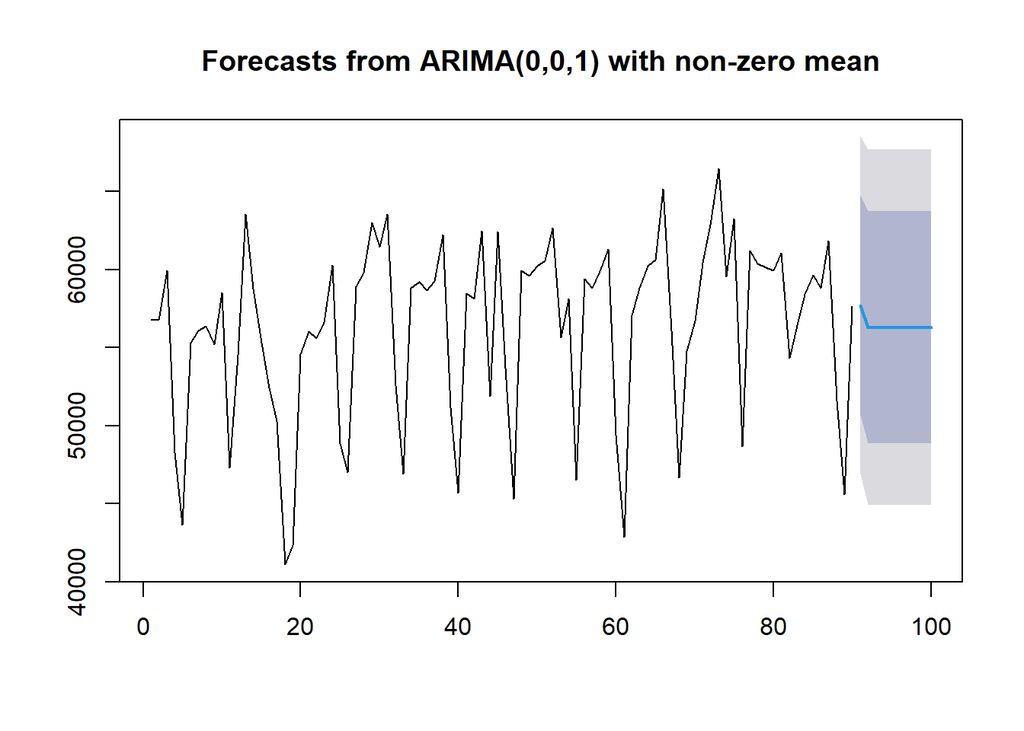

```r
data.ramalan <- ramalan$mean
plot(ramalan)
```

Berdasarkan hasil plot ramalan di atas, ramalan model ARIMA(0,0,1) menunjukkan nilai yang cepat kembali (revert) ke rata-rata data latih setelah periode pertama, sesuai karakteristik model MA(1) yang hanya memiliki memori jangka pendek. Selanjutnya, dapat dicari nilai akurasi antara hasil ramalan dengan data uji sebagai berikut.

```r
perbandingan <- data.frame(
  Aktual   = as.numeric(test.ts),
  Forecast = as.numeric(data.ramalan)
)
perbandingan
```

```
   Aktual Forecast
1   58409 57705.79
2   59505 56285.54
3   57890 56285.54
4   62276 56285.54
5   47895 56285.54
6   45718 56285.54
7   56785 56285.54
8   56860 56285.54
9   58354 56285.54
10  59612 56285.54
```

```r
# Akurasi
akurasi_test <- forecast::accuracy(as.numeric(data.ramalan), as.numeric(test.ts))
akurasi_test
```

```
               ME     RMSE      MAE       MPE     MAPE
Test set -97.1652 4973.095 3694.451 -1.061338 7.065308
```

Berdasarkan hasil perhitungan akurasi, diperoleh nilai MAPE sebesar 7,07% yang menunjukkan bahwa model ARIMA(0,0,1) cukup baik dalam meramalkan jumlah penumpang transportasi umum pada data uji, meskipun terdapat sedikit pola mingguan pada data yang belum sepenuhnya tertangkap oleh model ARIMA non-musiman ini.

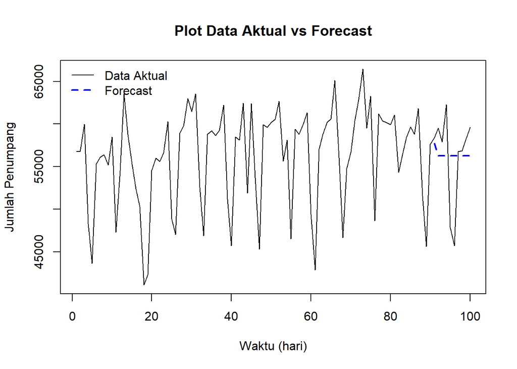

```r
# Plot data aktual vs forecast
ts.plot(dat.ts, col = "black", lty = 1,
        xlab = "Waktu (hari)", ylab = "Jumlah Penumpang",
        main = "Plot Data Aktual vs Forecast")

# Garis forecast
lines((n.train+1):n, as.numeric(data.ramalan), col = "blue", lty = 2, lwd = 2)
legend("topleft",
       legend = c("Data Aktual", "Forecast"),
       col = c("black", "blue"),
       lty = c(1,2), lwd = c(1,2), bty = "n")
```